# customizing the IPython contextual help

[@tonyfast](https://github.com/tonyfast) s notebooks

**title**

customizing the IPython contextual help

**description**

an original feature of pidgy is the use jupyters contextual help to provide wysiwyg experience.

**state**

executed in order

**kernel**

Python [conda env:root] *

**language**

python

**name**

`conda-root-py`

**outputs**

12

documentation

including the current markdown token

In [ ]

markdown

actions

```
# customizing the `IPython` contextual help

an original feature of `pidgy` is the use `jupyter`s contextual help to provide wysiwyg experience.

as author's write `pidgy` they reveal a preview of the output and explore variables in the workspace.

![image.png](attachment:b0883578-72be-44f4-96e8-c170ead6f971.png "screen shot of a the modified contextual help for a cell in this notebook.")
```

7

# customizing the contextual help

an original feature of `pidgy` is the use `jupyter` s contextual help to provide wysiwyg experience.

as author's write `pidgy` they reveal a preview of the output and explore variables in the workspace.

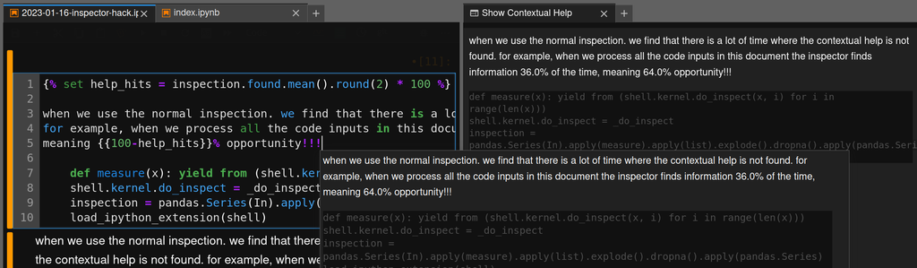

In [ ]

markdown

actions

```
* when source is found show help
* when inspection is found show the found results
* when is not found show the markdown preview
```

3

- when source is found show help
- when inspection is found show the found results
- when is not found show the markdown preview

In [ ]

markdown

actions

```
the inspector uses `jupyter`s rich display system.
we can send html and markdown to the contextual help.
```

2

the inspector uses `jupyter` s rich display system. we can send html and markdown to the contextual help.

In [ ]

markdown

actions

[output not shown]

2

In [ 1 ]

code

actions

```
    def load_ipython_extension(shell):
        __import__("nest_asyncio").apply() # just in case
        shell.enable_html_pager = True
        shell.kernel.do_inspect = types.MethodType(do_inspect, shell)
```

4

In [ 2 ]

code

actions

```
    %reload_ext pidgy
    import pandas
```

3

In [ ]

markdown

actions

```
for any of this to work need to enable the html pager [`shell.enable_html_pager`](https://ipython.readthedocs.io/en/stable/config/options/kernel.html#configtrait-ZMQInteractiveShell.enable_html_pager)
```

1

for any of this to work need to enable the html pager [`shell.enable_html_pager`](https://ipython.readthedocs.io/en/stable/config/options/kernel.html#configtrait-ZMQInteractiveShell.enable_html_pager)

In [ 3 ]

code

actions

```
    shell.enable_html_pager = True
```

1

```
shell.enable_html_pager = True
```

In [ ]

markdown

actions

```
`do_inspect` will be our new contextual help completer. it provides completion when:

* there is no content to inspect
* there was no result found
* you found [the bangs](#the-bangs)
```

5

`do_inspect` will be our new contextual help completer. it provides completion when:

- there is no content to inspect
- there was no result found
- you found the bangs

In [ 4 ]

code

actions

```
    def do_inspect(self, cell, cursor_pos, detail_level=1, omit_sections=(), *, cache={}):
        post = post_bangs(cell, get_bangs(cell, cursor_pos))
        if post:
            data = _do_inspect("", 0, detail_level=0, omit_sections=())
            data["data"]= post
            data["found"] = True
        else:
            data = _do_inspect(cell, cursor_pos, detail_level=0, omit_sections=())
            if not data["found"]:
                data.update(inspect_weave(cell, cursor_pos))
        return data
```

11

```
def do_inspect(self, cell, cursor_pos, detail_level=1, omit_sections=(), *, cache={}):
    post = post_bangs(cell, get_bangs(cell, cursor_pos))
    if post:
        data = _do_inspect("", 0, detail_level=0, omit_sections=())
        data["data"]= post
        data["found"] = True
    else:
        data = _do_inspect(cell, cursor_pos, detail_level=0, omit_sections=())
        if not data["found"]:
            data.update(inspect_weave(cell, cursor_pos))
    return data
```

In [ 5 ]

code

actions

```
    def inspect_weave(code, cursor_pos, cache={}):
        data = dict(found=True)
        if not code.strip():
            data["data"] = {"text/markdown": help}
        else:
            tokens = cache.get(code)
            line, offset= lineno_at_cursor(code, cursor_pos)
            if tokens is None:
                cache.clear()
                tokens = cache[code] = shell.tangle.parse(code)
            where = get_md_pointer(tokens, line, offset)
            data["data"] = {"text/markdown": F"""`{"/".join(where)}`\n\n{code}"""}
        return data
```

13

```
def inspect_weave(code, cursor_pos, cache={}):
    data = dict(found=True)
    if not code.strip():
        data["data"] = {"text/markdown": help}
    else:
        tokens = cache.get(code)
        line, offset= lineno_at_cursor(code, cursor_pos)
        if tokens is None:
            cache.clear()
            tokens = cache[code] = shell.tangle.parse(code)
        where = get_md_pointer(tokens, line, offset)
        data["data"] = {"text/markdown": F"""`{"/".join(where)}`\n\n{code}"""}
    return data
```

In [ ]

markdown

actions

```
this is a hack! we'll hold the original inspect function and monkey patch it.
```

1

this is a hack! we'll hold the original inspect function and monkey patch it.

In [ 6 ]

code

actions

```
    locals().setdefault("_do_inspect", shell.kernel.do_inspect)
```

1

```
<bound method IPythonKernel.do_inspect of <ipykernel.ipkernel.IPythonKernel object at 0x7fd8eb2b0fa0>>
```

```
locals().setdefault("_do_inspect", shell.kernel.do_inspect)
```

In [ 7 ]

code

actions

```
    if I := ("__file__" not in locals()): load_ipython_extension(shell)
```

1

```
if I := ("__file__" not in locals()): load_ipython_extension(shell)
```

In [ ]

markdown

actions

```
### line positions and tokenization

it seemed important to have line and column numbers that align exactly with the code mirror line numbers and the line/column number in the bottom inspector ribbon. for extra confidence when writing pidgy we include the markdown block token the cursor is within.
```

3

### line positions and tokenization

it seemed important to have line and column numbers that align exactly with the code mirror line numbers and the line/column number in the bottom inspector ribbon. for extra confidence when writing pidgy we include the markdown block token the cursor is within.

In [ 8 ]

code

actions

```
    def lineno_at_cursor(cell, cursor_pos=0):
        offset = 0
        for i, line in enumerate(cell.splitlines(True)):
            next_offset = offset + len(line)
            if not line.endswith('\n'): next_offset += 1
            if next_offset > cursor_pos:  break
            offset = next_offset
        col = cursor_pos-offset
        return i, col

    def get_md_pointer(tokens, line, offset):
        where = [F"L{line+1}:{offset+1}"]
        for node in tokens:
            if node.type == "root": continue
            if node.map:
                if line < node.map[0]: break
                elif node.map[0] <= line < node.map[1]: where.append(node.type)
        return where
```

18

```
def lineno_at_cursor(cell, cursor_pos=0):
    offset = 0
    for i, line in enumerate(cell.splitlines(True)):
        next_offset = offset + len(line)
        if not line.endswith('\n'): next_offset += 1
        if next_offset > cursor_pos:  break
        offset = next_offset
    col = cursor_pos-offset
    return i, col

def get_md_pointer(tokens, line, offset):
    where = [F"L{line+1}:{offset+1}"]
    for node in tokens:
        if node.type == "root": continue
        if node.map:
            if line < node.map[0]: break
            elif node.map[0] <= line < node.map[1]: where.append(node.type)
    return where
```

In [ ]

markdown

actions

```
## the bangs

the bangs give extra interactivity. when inspecting code a group of exclamation `!!!` points with template the woven source, or with enough emphasism `!!!!!!` we'll actually run code. consider these easter eggs cause i want them.
```

3

## the bangs

the bangs give extra interactivity. when inspecting code a group of exclamation `!!!` points with template the woven source, or with enough emphasism `!!!!!!` we'll actually run code. consider these easter eggs cause i want them.

In [ 9 ]

code

actions

```
    def get_bangs(cell, cursor_pos):
        if cell[cursor_pos-1] == "!":
            l, r = cell[:cursor_pos], cell[cursor_pos:]
            return len(l) - len(l.rstrip("!")) + len(r) - len(r.strip("!"))
        return 0
```

5

```
def get_bangs(cell, cursor_pos):
    if cell[cursor_pos-1] == "!":
        l, r = cell[:cursor_pos], cell[cursor_pos:]
        return len(l) - len(l.rstrip("!")) + len(r) - len(r.strip("!"))
    return 0
```

In [ 10 ]

code

actions

````
    def post_bangs(cell, bangs):
        if bangs>=6:
            result = shell.run_cell(cell, store_history=False, silent=True)
            error = result.error_before_exec or result.error_in_exec
            if error: return {"text/markdown": F"""```pycon\n{"".join(
                    traceback.format_exception(type(error), error, error.__traceback__)
                )}\n```"""}
            else: shell.weave.update()
        if bangs >=3:
            result = shell.environment.from_string(cell, None, pidgy.environment.IPythonTemplate)
            return {"text/markdown": result.render()}
````

11

````
def post_bangs(cell, bangs):
    if bangs>=6:
        result = shell.run_cell(cell, store_history=False, silent=True)
        error = result.error_before_exec or result.error_in_exec
        if error: return {"text/markdown": F"""```pycon\n{"".join(
                traceback.format_exception(type(error), error, error.__traceback__)
            )}\n```"""}
        else: shell.weave.update()
    if bangs >=3:
        result = shell.environment.from_string(cell, None, pidgy.environment.IPythonTemplate)
        return {"text/markdown": result.render()}
````

In [ ]

markdown

actions

```
## the opportunity in the misses

the contextual help renders on keypress when a result is found.
```

3

## the opportunity in the misses

the contextual help renders on keypress when a result is found.

In [ 11 ]

code

actions

```
{% set help_hits = inspection.found.mean().round(2) * 100 %}

when we use the normal inspection. we find that there is a lot of time where the contextual help is not found.
for example, when we process all the code inputs in this document the inspector finds information {{help_hits}}% of the time,
meaning {{100-help_hits}}% opportunity!!!

    def measure(x): yield from (shell.kernel.do_inspect(x, i) for i in range(len(x)))
    shell.kernel.do_inspect = _do_inspect
    inspection = pandas.Series(In).apply(measure).apply(list).explode().dropna().apply(pandas.Series)
    load_ipython_extension(shell)
```

10

when we use the normal inspection. we find that there is a lot of time where the contextual help is not found. for example, when we process all the code inputs in this document the inspector finds information 36.0% of the time, meaning 64.0% opportunity!!

```
def measure(x): yield from (shell.kernel.do_inspect(x, i) for i in range(len(x)))
shell.kernel.do_inspect = _do_inspect
inspection = pandas.Series(In).apply(measure).apply(list).explode().dropna().apply(pandas.Series)
load_ipython_extension(shell)
```

In [ 12 ]

code

actions

```
a use is the blank screen is to provide a help interface for people to learn our new tool.
with links to good docs.

    help =\
`pidgy` is markdown/python literate programming language.

* indented code and fenced code are executed

## documentation

* jinja2 documentation
* markdown documentation
* python documentation
```

13

a use is the blank screen is to provide a help interface for people to learn our new tool. with links to good docs.

```
help =\
```

`pidgy` is markdown/python literate programming language.

- indented code and fenced code are executed

## documentation

- jinja2 documentation
- markdown documentation
- python documentation

In [ ]

markdown

actions

```
## including the current markdown token

sometimes when writing `pidgy` its possible to lose your you position. we include the line number and token the cursor is in
```

3

## including the current markdown token

sometimes when writing `pidgy` its possible to lose your you position. we include the line number and token the cursor is in

In [ ]

markdown

actions

```
an accidental outcome is this _hack_ adds contextual help to markdown cells. its good.
```

1

an accidental outcome is this *hack* adds contextual help to markdown cells. its good.